# Quick evaluation Miguel scores, round 4

### Synopsis

#### Libraries

```r
dyn.load('/Library/Java/JavaVirtualMachines/jdk1.8.0_161.jdk/Contents/Home/jre/lib/server/libjvm.dylib')
library(rJava)
library(data.table)
library(ggplot2)
library(xlsx)
library(gridExtra)
library(splitstackshape)
```

### Upload data

```r
dsp_scored_rd1 <- unique(fread("../round1/DarkSpace-v1.txt",sep="\t",header=T,skip=1))
dsp_scored_rd2 <- unique(data.table(read.xlsx2("../round2/DarkSpace_rank2.xls",sheetIndex=1,header=T,colClasses = c("character","numeric","character","integer","character","numeric","numeric"))))
dsp_scored_rd3 <- unique(fread("../round3/pmid_ranks.txt",header=T,check.names = T))
dsp_scored_rd4 <- unique(fread("./pmid_ranks.txt",header = T,check.names = T))
```

### Preformat latest evaluation and the one before that

```r
dsp_scored_rd3 <- dsp_scored_rd3[,known:=ifelse(Known.pairs=="",
                                                "false",
                                                "true")]

dsp_scored_rd4 <- dsp_scored_rd4[,known:=ifelse(Known.pairs=="",
                                                "false",
                                                "true")]
table(dsp_scored_rd4$known,useNA = "ifany")
```

```
##
## false  true
## 80446 33869
```

### Explore data

I check the distribution of the relevance and the combined score separating IMEx positive and negative publications and comparing the previous iterations with the current one.

#### Relevance score plot

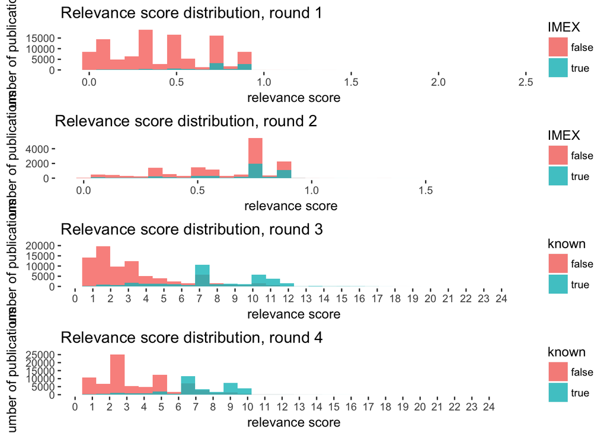

```r
g1 <- ggplot(dsp_scored_rd1,aes(x=Relevance,fill=IMEX))
g1 <- g1 + geom_histogram(alpha=0.8,position='identity')
g1 <- g1 + xlab("relevance score")
g1 <- g1 + ylab("Number of publications")
g1 <- g1 + ggtitle("Relevance score distribution, round 1")
#g1 <- g1 + xlim(0.0,2.0)
g1 <- g1 + theme(plot.title = element_text(),
               panel.grid.major = element_blank(),
               panel.grid.minor = element_blank(),
               panel.background = element_blank())

g2 <- ggplot(dsp_scored_rd2,aes(x=Relevance,fill=IMEX))
g2 <- g2 + geom_histogram(alpha=0.8,position='identity')
g2 <- g2 + xlab("relevance score")
g2 <- g2 + ylab("Number of publications")
g2 <- g2 + ggtitle("Relevance score distribution, round 2")
#g2 <- g2 + xlim(0.0,2.0)
g2 <- g2 + theme(plot.title = element_text(),
               panel.grid.major = element_blank(),
               panel.grid.minor = element_blank(),
               panel.background = element_blank())

g3 <- ggplot(dsp_scored_rd3,aes(x=Relevance,fill=known))
g3 <- g3 + geom_histogram(alpha=0.8,position='identity')
g3 <- g3 + xlab("relevance score")
g3 <- g3 + ylab("Number of publications")
g3 <- g3 + ggtitle("Relevance score distribution, round 3")
g3 <- g3 + scale_x_continuous(breaks=c(0:24))
g3 <- g3 + theme(plot.title = element_text(),
               panel.grid.major = element_blank(),
               panel.grid.minor = element_blank(),
               panel.background = element_blank())

g4 <- ggplot(dsp_scored_rd4,aes(x=Relevance,fill=known))
g4 <- g4 + geom_histogram(alpha=0.8,position='identity')
g4 <- g4 + xlab("relevance score")
g4 <- g4 + ylab("Number of publications")
g4 <- g4 + ggtitle("Relevance score distribution, round 4")
g4 <- g4 + scale_x_continuous(breaks=c(0:24))
g4 <- g4 + theme(plot.title = element_text(),
               panel.grid.major = element_blank(),
               panel.grid.minor = element_blank(),
               panel.background = element_blank())

grid.arrange(g1, g2, g3, g4, ncol=1)
```

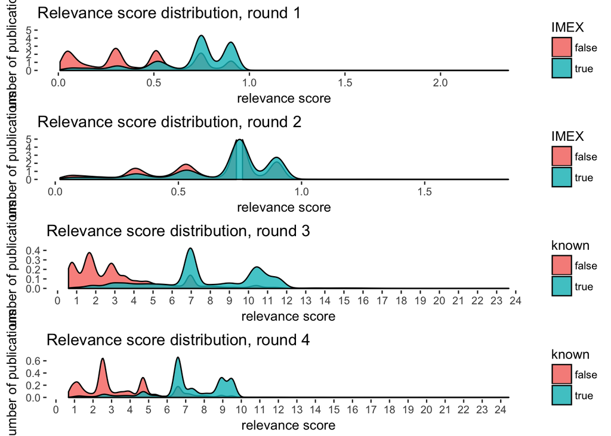

```r
g1.1 <- ggplot(dsp_scored_rd1,aes(x=Relevance,fill=IMEX))
g1.1 <- g1.1 + geom_density(alpha=0.8,position='identity')
g1.1 <- g1.1 + xlab("relevance score")
g1.1 <- g1.1 + ylab("Number of publications")
g1.1 <- g1.1 + ggtitle("Relevance score distribution, round 1")
#g1.1 <- g1.1 + xlim(0.0,2.0)
g1.1 <- g1.1 + ylim(0,5)
g1.1 <- g1.1 + theme(plot.title = element_text(),
               panel.grid.major = element_blank(),
               panel.grid.minor = element_blank(),
               panel.background = element_blank())

g2.1 <- ggplot(dsp_scored_rd2,aes(x=Relevance,fill=IMEX))
g2.1 <- g2.1 + geom_density(alpha=0.8,position='identity')
g2.1 <- g2.1 + xlab("relevance score")
g2.1 <- g2.1 + ylab("Number of publications")
g2.1 <- g2.1 + ggtitle("Relevance score distribution, round 2")
#g2.1 <- g2.1 + xlim(0.0,2.0)
g2.1 <- g2.1 + ylim(0,5)
g2.1 <- g2.1 + theme(plot.title = element_text(),
               panel.grid.major = element_blank(),
               panel.grid.minor = element_blank(),
               panel.background = element_blank())

g3.1 <- ggplot(dsp_scored_rd3,aes(x=Relevance,fill=known))
g3.1 <- g3.1 + geom_density(alpha=0.8,position='identity')
g3.1 <- g3.1 + xlab("relevance score")
g3.1 <- g3.1 + ylab("Number of publications")
g3.1 <- g3.1 + ggtitle("Relevance score distribution, round 3")
g3.1 <- g3.1 + scale_x_continuous(breaks=c(0:24))
g3.1 <- g3.1 + theme(plot.title = element_text(),
               panel.grid.major = element_blank(),
               panel.grid.minor = element_blank(),
               panel.background = element_blank())

g4.1 <- ggplot(dsp_scored_rd4,aes(x=Relevance,fill=known))
g4.1 <- g4.1 + geom_density(alpha=0.8,position='identity')
g4.1 <- g4.1 + xlab("relevance score")
g4.1 <- g4.1 + ylab("Number of publications")
g4.1 <- g4.1 + ggtitle("Relevance score distribution, round 4")
g4.1 <- g4.1 + scale_x_continuous(breaks=c(0:24))
g4.1 <- g4.1 + theme(plot.title = element_text(),
               panel.grid.major = element_blank(),
               panel.grid.minor = element_blank(),
               panel.background = element_blank())

grid.arrange(g1.1, g2.1, g3.1, g4.1, ncol=1)
```

The re-calculated score is distributed very similarly to the previous instance. I decide to manually evaluate slices of the distribution, to see whether the score correlates with uncurated interaction papers.

##### Select data for manual evaluation

I select slices of data from each of the interesting regions in the relevance score distribution.

```r
set.seed(888)
dsp_noimex_rd4 <- unique(dsp_scored_rd4[IMEX=="",.(pmid = X.PMID,
                                            Relevance,
                                            known,
                                            DB.score,
                                            Dark.Space.interest,
                                            Dark.Space..partial..interest)])

dsp_noimex_rd4 <- dsp_noimex_rd4[order(-Relevance)]

top_20 <- head(dsp_noimex_rd4[,slice:="top 20"],20)
top_10_unknown <-  head(dsp_noimex_rd4[known=="false"],13)
top_10_unknown <- tail(top_10_unknown,10)
top_10_unknown <- top_10_unknown[,slice:="top 10 unknown"]
relevance_9_area <- dsp_noimex_rd4[Relevance>9.1 & Relevance<9.6,]
relevance_9_area <- relevance_9_area[sample(1:nrow(relevance_9_area),10)]
relevance_9_area <- relevance_9_area[,slice:="relevance 9 area 1"]
relevance_9_area_2 <- dsp_noimex_rd4[Relevance>8.5 & Relevance<9,]
relevance_9_area_2 <- relevance_9_area_2[sample(1:nrow(relevance_9_area_2),10)]
relevance_9_area_2 <- relevance_9_area_2[,slice:="relevance 9 area 2"]
relevance_7_area <- dsp_noimex_rd4[Relevance>6.5 & Relevance<7,]
relevance_7_area <- relevance_7_area[sample(1:nrow(relevance_7_area),10)]
relevance_7_area <- relevance_7_area[,slice:="relevance 7 area 1"]
relevance_7_area_2 <- dsp_noimex_rd4[Relevance>6 & Relevance<6.5,]
relevance_7_area_2 <- relevance_7_area_2[sample(1:nrow(relevance_7_area_2),10)]
relevance_7_area_2 <- relevance_7_area_2[,slice:="relevance 7 area 2"]
relevance_5_area <- dsp_noimex_rd4[Relevance>4.25 & Relevance<4.75,]
relevance_5_area <- relevance_5_area[sample(1:nrow(relevance_5_area),10)]
relevance_5_area <- relevance_5_area[,slice:="relevance 5 area"]
relevance_2_area <- dsp_noimex_rd4[Relevance>2.25 & Relevance<2.75,]
relevance_2_area <- relevance_2_area[sample(1:nrow(relevance_2_area),10)]
relevance_2_area <- relevance_2_area[,slice:="relevance 2 area"]
relevance_1_area <- dsp_noimex_rd4[Relevance>0.75 & Relevance<1.25,]
relevance_1_area <- relevance_1_area[sample(1:nrow(relevance_1_area),10)]
relevance_1_area <- relevance_1_area[,slice:="relevance 1 area"]
bottom_10_area <- tail(dsp_noimex_rd4[,slice:="bottom 10"],10)

manual_eval <- unique(rbind(top_20,
                            top_10_unknown,
                            relevance_9_area,
                            relevance_9_area_2,
                            relevance_7_area,
                            relevance_7_area_2,
                            relevance_5_area,
                            relevance_2_area,
                            relevance_1_area,
                            bottom_10_area))
fwrite(manual_eval,
       "./to_eval_manual.txt",
       col.names = T,
       row.names = F,
       quote = F,
       sep = "\t")
```

#### Explore manually evaluated subset

I have a closer look, taking into account the origin of the data and comparing with previous version of the score.

##### Upload manual evaluation

```r
manual <- fread("./manual.txt",header = T)

manual$pmid <- as.character(manual$pmid)
manual$id <- manual[,.(.I)]
```

##### Obtain DSP comparison table for reference

I will take the table that does the comparison at the publication level only for this comparison.

```r
if(!exists("dsp_pubcomp")){
        setwd("~/Documents/Projects/dsp/darkspaceproject/dsp_comparison/results/")
        dsp_pubcompNames = fread('cat pubcomp_table_final.txt.gz | gunzip | head -n 1')[, colnames(.SD)]
        dsp_pubcomp = fread('cat pubcomp_table_final.txt.gz | gunzip | grep -v "^Day"')
        setnames(dsp_pubcomp, dsp_pubcompNames)
        setwd("~/Documents/Projects/dsp/DarkSpace/manual_evaluation/round2/")
}
```

##### Merge origin into manual evaluation

```r
manual_ori <- data.table(unique(merge(manual,dsp_pubcomp,by="pmid",all.x=T,all.y=F)))
manual_ori <- manual_ori[order(id)]

fwrite(manual_ori,"./manual_ori.txt",col.names = T,row.names = F,quote=F,sep="\t")
```

##### Plot manual evaluation

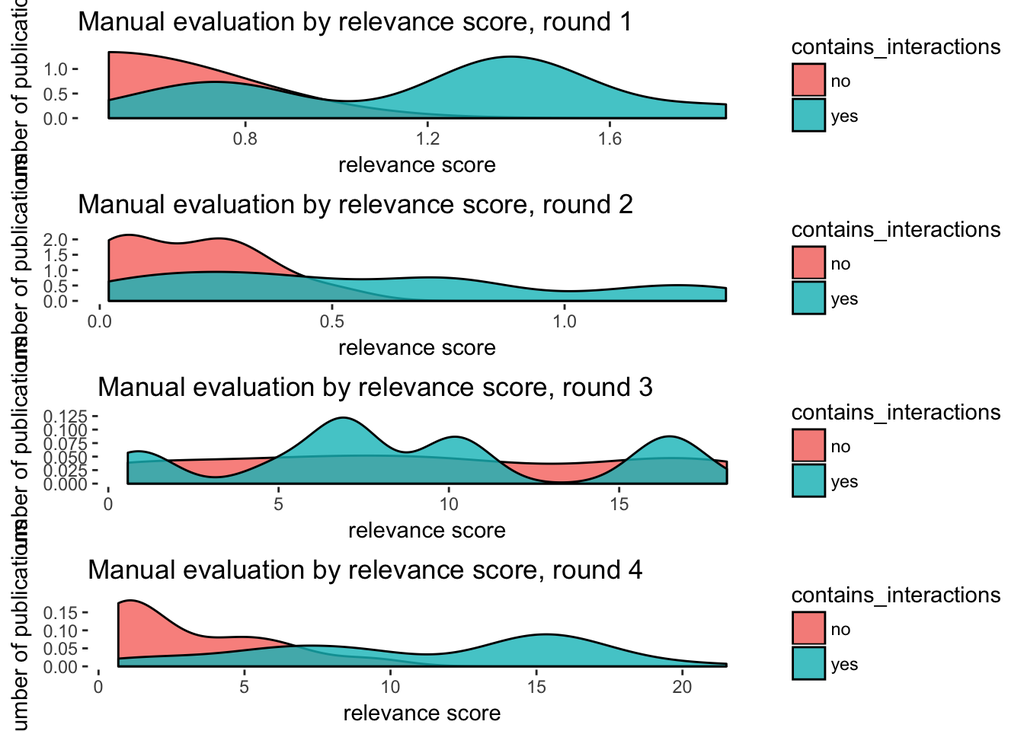

```r
manual_ori_sel <- unique(manual_ori[,.(pmid,
                                        relevance,
                                        contains_interactions,
                                        id,
                                        tm_epmc = ifelse(tm_epmc=="1",
                                                         "tm_epmc",
                                                         "0"),
                                        EVEX = ifelse(EVEX=="1",
                                                         "EVEX",
                                                         "0"),
                                        reactome = ifelse(reactome=="1",
                                                         "reactome",
                                                         "0"),
                                        OP_int =  ifelse(OmniPath_interactions=="1",
                                                         "OP_int",
                                                         "0"),
                                        OP_ptm =  ifelse(OmniPath_ptm=="1",
                                                         "OP_ptm",
                                                         "0")),
                                    round])

manual_ori_sel_long <- reshape(manual_ori_sel,direction="long",v.names="origin",varying=c("tm_epmc","EVEX","reactome","OP_int","OP_ptm"))
manual_ori_sel_long <- unique(manual_ori_sel_long[order(id,-origin),.(id,
                                                             pmid,
                                                             relevance,
                                                             contains_interactions,
                                                             origin,
                                                             round,
                                                             select="yes")])


for (i in 2:nrow(manual_ori_sel_long)){
        if(manual_ori_sel_long[i,]$pmid == manual_ori_sel_long[i-1,]$pmid & manual_ori_sel_long[i,]$origin=="0"){
                manual_ori_sel_long[i,]$select <- "no"
        }

}

manual_ori_sel_long <- manual_ori_sel_long[select=="yes"]

manual_ori_sel_long_simple <- manual_ori_sel_long[,.(id,
                                              pmid,
                                              relevance,
                                              contains_interactions = ifelse(grepl("no",contains_interactions),
                                                                             "no",
                                                                             "yes"),
                                              origin,
                                              round,
                                              select)]

g5.1 <- ggplot(manual_ori_sel_long_simple[round=="rd1"],aes(x=relevance,fill=contains_interactions))
g5.1 <- g5.1 + geom_density(alpha=0.8,position='identity')
g5.1 <- g5.1 + xlab("relevance score")
g5.1 <- g5.1 + ylab("Number of publications")
g5.1 <- g5.1 + ggtitle("Manual evaluation by relevance score, round 1")
g5.1 <- g5.1 + theme(plot.title = element_text(),
               panel.grid.major = element_blank(),
               panel.grid.minor = element_blank(),
               panel.background = element_blank())

g5.2 <- ggplot(manual_ori_sel_long_simple[round=="rd2"],aes(x=relevance,fill=contains_interactions))
g5.2 <- g5.2 + geom_density(alpha=0.8,position='identity')
g5.2 <- g5.2 + xlab("relevance score")
g5.2 <- g5.2 + ylab("Number of publications")
g5.2 <- g5.2 + ggtitle("Manual evaluation by relevance score, round 2")
g5.2 <- g5.2 + theme(plot.title = element_text(),
               panel.grid.major = element_blank(),
               panel.grid.minor = element_blank(),
               panel.background = element_blank())

g5.3 <- ggplot(manual_ori_sel_long_simple[round=="rd3"],aes(x=relevance,fill=contains_interactions))
g5.3 <- g5.3 + geom_density(alpha=0.8,position='identity')
g5.3 <- g5.3 + xlab("relevance score")
g5.3 <- g5.3 + ylab("Number of publications")
g5.3 <- g5.3 + ggtitle("Manual evaluation by relevance score, round 3")
g5.3 <- g5.3 + theme(plot.title = element_text(),
               panel.grid.major = element_blank(),
               panel.grid.minor = element_blank(),
               panel.background = element_blank())

g5.4 <- ggplot(manual_ori_sel_long_simple[round=="rd4"],aes(x=relevance,fill=contains_interactions))
g5.4 <- g5.4 + geom_density(alpha=0.8,position='identity')
g5.4 <- g5.4 + xlab("relevance score")
g5.4 <- g5.4 + ylab("Number of publications")
g5.4 <- g5.4 + ggtitle("Manual evaluation by relevance score, round 4")
g5.4 <- g5.4 + theme(plot.title = element_text(),
               panel.grid.major = element_blank(),
               panel.grid.minor = element_blank(),
               panel.background = element_blank())

grid.arrange(g5.1, g5.2, g5.3, g5.4, ncol=1)
```

###### Plot manual evalutation by data source

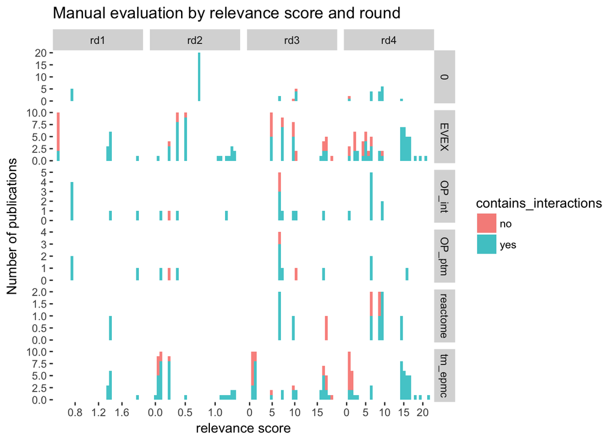

```r
g6 <- ggplot(manual_ori_sel_long_simple,aes(x=relevance,fill=contains_interactions))
g6 <- g6 + geom_histogram(alpha=0.8,position='stack')
g6 <- g6 + xlab("relevance score")
g6 <- g6 + ylab("Number of publications")
g6 <- g6 + ggtitle("Manual evaluation by relevance score and round")
g6 <- g6 + facet_grid(origin~round,scales="free")
g6 <- g6 + theme(plot.title = element_text(),
               panel.grid.major = element_blank(),
               panel.grid.minor = element_blank(),
               panel.background = element_blank())
g6
```

Numbers are a bit low to draw final conclusions, but it seems that the fourth iteration of the relevance score can distinguish between papers containing interaction data regardless of the origin of the data .

We can use this interation as input for the DSP curation pipeline.